# Simulation benchmark: a coherent functional shift on non-overlapping accessions

Yixuan Yang

The methodological test of `repdist`: a functional shift with a known truth, carried by accessions no two samples share. The simulation page works one such design through in full on ten CATH FunFams; this page repeats the test on experimentally characterised enzyme classes, with every eligible EC3 as the target.

```r
library(ggplot2)
bm <- readRDS("simulation_benchmark.rds")
u <- readRDS("microbial_ec_universe.rds")
```

# Design

- **Universe.** 1400 bacterial and archaeal UniProtKB enzymes (release 2026_03) whose EC number sits on a catalytic-activity reaction with experimental evidence (ECO:0000269), one EC3 each, one per UniRef50 cluster; every EC3 with at least 50 such proteins, 50 of each (28 EC3s). Embedded with TM-Vec. `README.md` beside this page gives every selection rule.
- **Groups.** Ten samples each. Every group A sample upregulates 5 private proteins of the target EC3; every group B sample 5 private proteins from distinct other EC3s. No accession is upregulated twice, every protein is in every sample, and group B’s k-th sample takes the baseline abundances of group A’s k-th, so the groups move the same amount of abundance.
- **Counts.** Negative binomial: lognormal baseline abundance, lognormal size factors, a DESeq2-style mean–dispersion trend with scatter, and a 31-fold mean increase on upregulated proteins, which makes the target EC3’s group-mean aggregate exactly 4 times baseline.
- **Methods.** Protein-level Bray-Curtis; RBF-MMD (`sample_mmd()`); Bray-Curtis on MCL bins (`protein_similarity()` with `min_sim` 0.5 and no coverage gate, then `bin_proteins()` with `inflation` 2); DESeq2 at protein and bin level. Summing by true EC3 is the oracle.
- **Repeats.** Every EC3 as the target, one seed each: 28 simulations.

The clustering never sees the EC3 labels; they are used only to score.

# Sample-level separation

```r
s <- bm$separation
tab <- do.call(rbind, lapply(split(s, s$distance), function(x) {
  data.frame(distance = x$distance[1], detected = mean(x$p < 0.05),
             median_R2 = median(x$R2),
             dispersion_differs = mean(x$permdisp_p < 0.05))
}))
tab <- tab[order(-tab$median_R2), ]
knitr::kable(tab, row.names = FALSE, digits = 3)
```

| distance | detected | median_R2 | dispersion_differs |
| --- | --- | --- | --- |
| Bray-Curtis (EC3 oracle) | 1.000 | 0.318 | 0.821 |
| Bray-Curtis (MCL bins) | 0.714 | 0.136 | 0.214 |
| RBF-MMD | 0.964 | 0.115 | 0.000 |
| Bray-Curtis (protein) | 0.036 | 0.053 | 0.000 |

`detected`: share of targets with PERMANOVA $p < 0.05$ (999 permutations). `dispersion_differs`: share with PERMDISP $p < 0.05$, where part of a PERMANOVA difference can be spread rather than location. $R^2$ is unchanged by multiplying a distance by a constant, so the rows can be compared descriptively; the distances encode different geometries, so read gaps between them with that in mind.

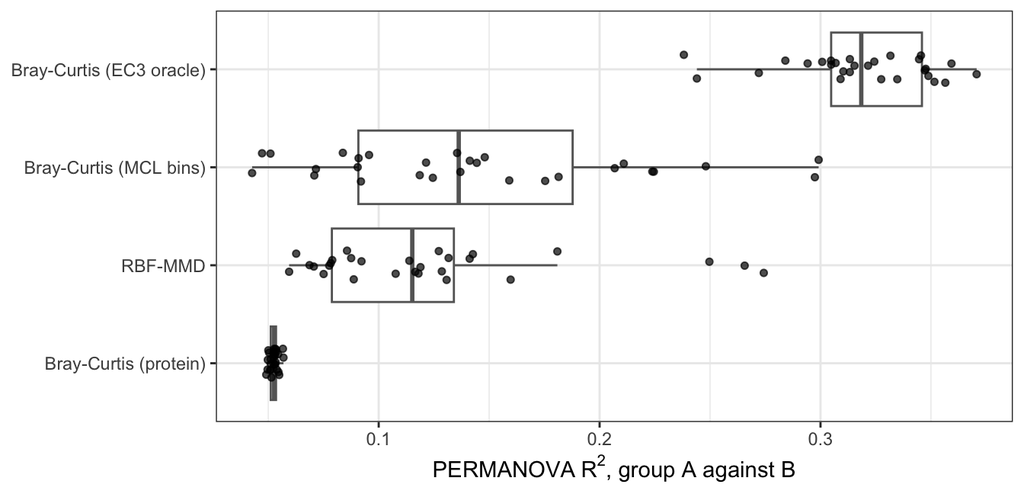

```r
s$distance <- factor(s$distance, rev(tab$distance))
ggplot(s, aes(R2, distance)) +
  geom_boxplot(outlier.shape = NA, colour = "grey40") +
  geom_jitter(height = 0.15, size = 1.3, alpha = 0.7) +
  labs(x = expression(PERMANOVA ~ R^2 * ", group A against B"), y = NULL) +
  theme_bw()
```

Separation follows the target’s structural coherence, the median predicted TM-score between its own members (Spearman correlation with $R^2$):

```r
Z <- u$embeddings / sqrt(rowSums(u$embeddings^2))
ec3 <- setNames(u$members$ec3, u$members$protein)
coherence <- vapply(split(names(ec3), ec3), function(ids) {
  S <- tcrossprod(Z[ids, ])
  median(S[upper.tri(S)])
}, numeric(1))
round(vapply(split(bm$separation, bm$separation$distance), function(x)
  cor(x$R2, coherence[x$target], method = "spearman"), numeric(1)), 2)
```

```
#> Bray-Curtis (EC3 oracle)   Bray-Curtis (MCL bins)    Bray-Curtis (protein)
#>                     0.22                     0.39                     0.13
#>                  RBF-MMD
#>                     0.58
```

# Differential abundance

```r
sc <- bm$scores
knitr::kable(data.frame(
  measure = c("protein level: target proteins significant (total of 1,400)",
              "protein level: any protein significant (mean per target)",
              "MCL bins: targets with a significant target-dominated bin",
              "MCL bins: recall of the upregulated target proteins (mean)",
              "MCL bins: significant bins higher in group B (total)",
              "EC3 oracle: targets significant"),
  value = c(sum(sc$protein_sig_target), mean(sc$protein_sig),
            sum(sc$bin_sig_up_a_target > 0), mean(sc$bin_recall),
            sum(sc$bin_sig_up_b), sum(sc$oracle_padj < 0.05))
), digits = 3)
```

| measure | value |
| --- | --- |
| protein level: target proteins significant (total of 1,400) | 290.000 |
| protein level: any protein significant (mean per target) | 23.750 |
| MCL bins: targets with a significant target-dominated bin | 21.000 |
| MCL bins: recall of the upregulated target proteins (mean) | 0.416 |
| MCL bins: significant bins higher in group B (total) | 13.000 |
| EC3 oracle: targets significant | 28.000 |

Per target, sorted by MCL-bin recall. `target_completeness` is the share of the target EC3 in its largest bin; `target_bins` the number of bins it spans.

```r
sc$coherence <- round(coherence[sc$target], 3)
knitr::kable(sc[order(-sc$bin_recall),
                c("target", "coherence", "target_bins", "target_completeness",
                  "bin_recall", "bin_sig_up_a_target", "target_bin_padj",
                  "target_bin_rank")],
             row.names = FALSE, digits = 3)
```

| target | coherence | target_bins | target_completeness | bin_recall | bin_sig_up_a_target | target_bin_padj | target_bin_rank |
| --- | --- | --- | --- | --- | --- | --- | --- |
| 4.2.3 | 0.453 | 6 | 0.66 | 0.96 | 4 | 0.000 | 1 |
| 5.6.2 | 0.362 | 7 | 0.58 | 0.94 | 5 | 0.000 | 1 |
| 6.2.1 | 0.742 | 5 | 0.76 | 0.92 | 3 | 0.000 | 1 |
| 2.6.1 | 0.705 | 3 | 0.90 | 0.90 | 1 | 0.000 | 1 |
| 3.1.3 | 0.436 | 5 | 0.76 | 0.76 | 0 | 0.005 | 1 |
| 3.1.1 | 0.480 | 5 | 0.74 | 0.74 | 0 | 0.000 | 1 |
| 5.1.1 | 0.336 | 5 | 0.42 | 0.72 | 1 | 0.035 | 2 |
| 1.2.1 | 0.707 | 3 | 0.68 | 0.68 | 1 | 0.000 | 1 |
| 6.3.2 | 0.346 | 8 | 0.38 | 0.66 | 2 | 0.000 | 1 |
| 1.14.13 | 0.382 | 9 | 0.54 | 0.54 | 1 | 0.000 | 1 |
| 1.5.1 | 0.391 | 5 | 0.48 | 0.50 | 2 | 0.105 | 5 |
| 4.2.1 | 0.351 | 14 | 0.34 | 0.46 | 1 | 0.033 | 3 |
| 2.7.7 | 0.369 | 13 | 0.30 | 0.42 | 4 | 0.377 | 26 |
| 3.5.2 | 0.376 | 8 | 0.36 | 0.40 | 2 | 0.000 | 1 |
| 2.3.1 | 0.356 | 7 | 0.32 | 0.38 | 3 | 0.788 | 53 |
| 1.13.11 | 0.381 | 10 | 0.30 | 0.28 | 1 | 0.718 | 33 |
| 2.7.1 | 0.363 | 6 | 0.48 | 0.28 | 2 | 0.159 | 9 |
| 2.4.1 | 0.389 | 5 | 0.52 | 0.26 | 0 | 0.210 | 7 |
| 3.6.1 | 0.376 | 10 | 0.38 | 0.22 | 1 | 0.825 | 51 |
| 4.1.1 | 0.347 | 11 | 0.36 | 0.18 | 2 | 0.493 | 9 |
| 3.2.1 | 0.366 | 9 | 0.46 | 0.14 | 1 | 0.445 | 12 |
| 5.1.3 | 0.375 | 10 | 0.34 | 0.12 | 1 | 0.973 | 54 |
| 2.4.2 | 0.372 | 11 | 0.40 | 0.10 | 3 | 0.600 | 35 |
| 3.5.1 | 0.379 | 7 | 0.44 | 0.08 | 1 | 0.770 | 40 |
| 1.1.1 | 0.489 | 4 | 0.90 | 0.00 | 0 | 0.222 | 4 |
| 2.1.1 | 0.431 | 5 | 0.82 | 0.00 | 0 | 0.348 | 7 |
| 2.5.1 | 0.364 | 12 | 0.26 | 0.00 | 0 | 0.802 | 32 |
| 5.3.1 | 0.413 | 5 | 0.56 | 0.00 | 0 | 0.906 | 48 |

# Sensitivity to the edge floor and inflation

Averaged over targets and scored with the labels. The reference setting was fixed before this ran; this table shows how the parameters move the result and is not used to choose them.

```r
sens <- aggregate(
  cbind(bins, in_multi_bins, ec3_purity, target_completeness, bin_recall,
        recovered = bin_sig_up_a_target > 0, bin_sig_up_b) ~
    min_sim + inflation,
  data = bm$sensitivity, FUN = mean)
knitr::kable(sens[order(sens$min_sim, sens$inflation), ],
             row.names = FALSE, digits = 2)
```

| min_sim | inflation | bins | in_multi_bins | ec3_purity | target_completeness | bin_recall | recovered | bin_sig_up_b |
| --- | --- | --- | --- | --- | --- | --- | --- | --- |
| 0.4 | 1.4 | 4 | 1.00 | 0.04 | 0.99 | 0.01 | 0.07 | 0.26 |
| 0.4 | 2.0 | 15 | 1.00 | 0.10 | 0.92 | 0.05 | 0.25 | 0.21 |
| 0.4 | 4.0 | 23 | 1.00 | 0.17 | 0.68 | 0.15 | 0.36 | 0.43 |
| 0.5 | 1.4 | 43 | 1.00 | 0.33 | 0.56 | 0.30 | 0.68 | 0.39 |
| 0.5 | 2.0 | 59 | 1.00 | 0.40 | 0.52 | 0.42 | 0.75 | 0.46 |
| 0.5 | 4.0 | 139 | 0.98 | 0.60 | 0.41 | 0.54 | 0.96 | 1.04 |
| 0.6 | 1.4 | 129 | 0.98 | 0.61 | 0.43 | 0.55 | 0.96 | 1.18 |
| 0.6 | 2.0 | 152 | 0.98 | 0.64 | 0.40 | 0.60 | 0.96 | 1.32 |
| 0.6 | 4.0 | 198 | 0.97 | 0.69 | 0.37 | 0.61 | 1.00 | 1.64 |
| 0.7 | 1.4 | 270 | 0.92 | 0.73 | 0.35 | 0.66 | 1.00 | 2.93 |
| 0.7 | 2.0 | 289 | 0.92 | 0.75 | 0.33 | 0.69 | 1.00 | 3.36 |
| 0.7 | 4.0 | 330 | 0.91 | 0.80 | 0.31 | 0.69 | 1.00 | 3.25 |

1 of 336 grid fits failed in DESeq2 and are left out of the means.

# Reading

- A coherent shift on private accessions is invisible to identity at the sample level: protein-level Bray-Curtis detects it at about its false-positive rate. At protein level, DESeq2 finds a share of the upregulated proteins one at a time, at a 31-fold change on a single sample each.
- RBF-MMD detects the shift for nearly every target, and more strongly the more structurally coherent the target EC3. An EC3 whose members span several folds gives it least to read.
- MCL bins make part of the shift testable as units. At the reference floor of 0.5 the target EC3 spreads over several bins; higher floors and inflations give purer, finer bins and recover more of the target, at the cost of more significant bins in group B; a floor of 0.4 collapses everything into a few bins.
- A bin is a community in a predicted-TM similarity graph, not a functional family; EC3 is the truth only because this is a simulation.

# Reproducing

Run from the `gh-pages` branch root with the current `repdist` installed: `Rscript validation/benchmark_simulation.R` regenerates `simulation_benchmark.rds` (about 5 minutes), and `validation/prepare_microbial_ec_universe.R` rebuilds the universe from UniProt. The session that produced these results:

```r
cat(head(bm$session, 3), sep = "\n")
```

[output not shown]